# What is grounded theory? | Evidence-Based Nursing

[figure not shown]

[figure not shown]

Research made simple

What is grounded theory?

Free

1. Helen Noble1,
2. Gary Mitchell2
1. Correspondence to : **Dr Helen Noble**  
   , School of Nursing and Midwifery, Queens's University Belfast, Belfast BT9 7BL, UK; Helen.noble@qub.ac.uk

http://dx.doi.org/10.1136/eb-2016-102306

[figure not shown]

## Introduction

Grounded theory (GT) is a research method concerned with the generation of theory,1 which is ‘grounded’ in data that has been systematically collected and analysed.2 It is used to uncover such things as social relationships and behaviours of groups, known as social processes.3 It was developed in California, USA by Glaser and Strauss during their study—‘Awareness of Dying’.1 It is a general methodology for developing theory that is grounded in data which is systematically gathered and analysed.

## Features of GT

- Data collection and analysis occur simultaneously.
- Categories and analytic codes developed from data. Pre-existing conceptualisations not to be used—this is known as theoretical sensitivity (see below).
- Theoretical sampling used to refine categories.
- Abstract categories constructed inductively.
- Social processes discovered in the data.
- Analytical memos used between coding and writing.
- Categories integrated into a theoretical framework.4

## Carrying out a GT study

First the area of interest is identified. Theoretical preconceptions should be avoided, although it is accepted this is difficult in practice. Analytical procedures and sampling strategies are then used and the study is finished when theoretical sampling reached5 all discussed below. Data collected may be qualitative or quantitative or a combination of both. Data collection methods often include in-depth interviews using open-ended questions. Questions can be adjusted as theory emerges. Observational methods and focus groups may also be used.

## Theoretical sampling

Glaser and Strauss (1967) first mentioned theoretical sampling and described a process of generating theory from data which includes collecting the data, then coding and analysing the data.1 Next the researcher makes a conscious decision about what further detail they feel needs exploring as the new theory develops. It usually takes place after some initial key concepts or categories have been identified, for example, you might decide to interview patients about their experience of heart failure. They may talk about systematic errors occurring in the general practice surgery. From this analysis of the data you may decide to approach and interview GPs to explore their views on patients’ comments. Theoretical sampling therefore, is used to produce more data to endorse or refute the categories that have been identified in the previous analysis.6

## Theoretical sensitivity

Theoretical sensitivity refers to the insight of the researcher. It concerns the researcher being able to give meaning to data, understand what the data says, and being able to separate out what is relevant and what is not. By being theoretically sensitive and using insight, the researcher is able to develop a theory that is grounded, theoretically dense, and cohesive.7 Sensitivity comes from several sources including (1) literature—in depth reading offers a rich understanding of the phenomena being studied; (2) professional and personal experience—offers an understanding of the events and topics being explored; (3) the analytic process—allows for insight and understanding of the phenomena.8

## Analysis of data in GT

There are three stages of data analysis in GT:8

1. Open coding: this involves line by line coding where concepts and key phrases are identified and highlighted and moved into subcategories, then categories. This breaks the data down into conceptual components and the researcher can start to theorise or reflect on what they are reading and understanding—making sense of the data. The data from each participant will be ‘constantly compared’ for similarities.
2. Axial coding: at this stage relationships are identified between the categories, and connections identified.
3. Selective coding: this involves identifying the core category and methodically relating it to other categories. The relationships must be authenticated and categories refined. Categories are then integrated together and a GT identified.

Analytical notes are encouraged. These are notes to oneself to explain thought patterns in relation to the data analysis. Final theory is usually generated from the integration of several analytical memos.

## The core category

The core category is the chief phenomena around which the categories are built. Theory is generated around a core category. The core category should account for the variation found in the data, that is, the categories will relate to it in some way. The categories demonstrate how the core category is situated in the lives of those participating in the study.

## Example of a GT case study

As illustrated, GT methodologies involve the construction of new theory through the analysis of data. In a study carried out by Beech *et al*,9 the authors sought to explore patient participant experiences of recovery following surgical intervention for colorectal cancer. Beech *et al*9 opted to use GT because previous studies had sought to answer this research question by measuring quantifiable biomedical markers, such as symptoms of pain, insomnia or fatigue. According to the authors, there was a paucity of empirical literature around the topic from a holistic perspective, for example social, psychological and cultural aspects of a person's well-being.

Twelve participants were interviewed four times, over a 1-year period. The authors used theoretical sampling to guide the researcher as data were collected. It helped facilitate the development of theory as it emerged, not once data collection was complete.1 Initial participants were selected based on ‘subject area’, as is recommended in theoretical sampling. Each had undergone a surgical procedure to remove a tumour in their bowel or rectum and had not received prescribed chemotherapy or radiotherapy. The authors initially asked patient participants to describe their experiences to date.

Data analysis of the interviews was carried out according to the steps described by Strauss and Corbin.10 The authors began by coding each line of each patient participant transcript. Similar codes were then grouped together to form subcategories and within these subcategories categories were identified. The authors then grouped together the categories to form theory related to patient participant experiences of recovery following surgical intervention for colorectal cancer. The process of data collection continued until each category was saturated and no new data emerged.

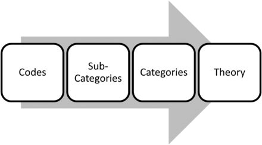

Figure 1

Grounded theory data analysis.

## Summary

By using GT and adhering to this as a research method, a theory will be produced that is grounded in your data.10 It is a research method which uses strict procedures for data analysis and will enable you to search for and conceptualise the hidden social and collective patterns and constructions in your area of interest.

## References

1. ↵
   1. Glaser BG,
   2. Strauss AL

   . The discovery of grounded theory: Strategies for qualitative research New York: Aldine de Gruyter, 1967.

   [Google Scholar](https://ebn.bmj.com/lookup/google-scholar?link_type=googlescholar&gs_type=article&q_txt=.+The+discovery+of+grounded+theory%3A+Strategies+for+qualitative+research+New+York%3A+Aldine+de+Gruyter%2C+1967.)
2. ↵
   1. Strauss A,
   2. Corbin J

   . Grounded theory methodology: an overview. In: Denzin NK, Lincoln YS, eds. Handbook of qualitative research. London: Sage Publications, 1994:1–18.

   [Google Scholar](https://ebn.bmj.com/lookup/google-scholar?link_type=googlescholar&gs_type=article&author[0]=A+Strauss&author[1]=J+Corbin&title=Grounded+theory+methodology:+an+overview&publication_year=1994&pages=1-18)
3. ↵
   1. Crooks DL

   . The importance of symbolic interaction in grounded theory research on women's health. Health Care for Women International, 2001;22:11–27.

   [CrossRef](https://ebn.bmj.com/lookup/external-ref?access_num=10.1080/073993301300003054&link_type=DOI)[PubMed](https://ebn.bmj.com/lookup/external-ref?access_num=11813790&link_type=MED&atom=%2Febnurs%2F19%2F2%2F34.atom)Google Scholar
4. ↵
   1. Charmaz K

   . “Grounded theory”. In: Smith J, et al. eds. Rethinking methods in psychology. London: Sage, 1995:27–49.

   [Google Scholar](https://ebn.bmj.com/lookup/google-scholar?link_type=googlescholar&gs_type=article&author[0]=K+Charmaz&title=%E2%80%9CGrounded+theory%E2%80%9D&publication_year=1995&pages=27-49)
5. ↵
   1. Dey I

   . Grounding Grounded Theory Guidelines for Qualitative Inquiry, San Diego: Academic Press, 1990.

   [Google Scholar](https://ebn.bmj.com/lookup/google-scholar?link_type=googlescholar&gs_type=article&q_txt=.+Grounding+Grounded+Theory+Guidelines+for+Qualitative+Inquiry%2C+San+Diego%3A+Academic+Press%2C+1990.)
6. ↵
   1. Charmaz K

   . “Discovering” chronic illness: Using grounded theory Social Science and Medicine 1990;30:1161–72.

   CrossRefGoogle Scholar
7. ↵
   1. Glaser B

   . Theoretical sensitivity. Mill Valley, CA: Sociology Press, 1978.

   [Google Scholar](https://ebn.bmj.com/lookup/google-scholar?link_type=googlescholar&gs_type=article&q_txt=.+Theoretical+sensitivity.+Mill+Valley%2C+CA%3A+Sociology+Press%2C+1978.)
8. ↵
   1. Strauss A,
   2. Corbin J

   . Basics of qualitative research: grounded theory procedures and techniques. Sage Publications, 1990.

   [Google Scholar](https://ebn.bmj.com/lookup/google-scholar?link_type=googlescholar&gs_type=article&q_txt=.+Basics+of+qualitative+research%3A+grounded+theory+procedures+and+techniques.+Sage+Publications%2C+1990.)
9. ↵
   1. Beech N,
   2. Arber A,
   3. Faithfull S

   . Restoring a sense of wellness following colorectal cancer: a grounded theory. Journal of Advanced Nursing 2012;68:1134–44. [doi:10.1111/j.1365-2648.2011.05820.x](http://dx.doi.org/10.1111/j.1365-2648.2011.05820.x)

   [CrossRef](https://ebn.bmj.com/lookup/external-ref?access_num=10.1111/j.1365-2648.2011.05820.x&link_type=DOI)[PubMed](https://ebn.bmj.com/lookup/external-ref?access_num=21895739&link_type=MED&atom=%2Febnurs%2F19%2F2%2F34.atom)Google Scholar
10. ↵
    1. Strauss A,
    2. Corbin J

    . Grounded theory methodology: an overview. In: Denzin N, Lincoln Y, eds. Strategies of qualitative inquiry. Thousand Oaks: Sage, 1998:158–83.

    [Google Scholar](https://ebn.bmj.com/lookup/google-scholar?link_type=googlescholar&gs_type=article&author[0]=A+Strauss&author[1]=J+Corbin&title=Grounded+theory+methodology:+an+overview&publication_year=1998&pages=158-83)

## Footnotes

- Competing interests None declared.
- Provenance and peer review Not commissioned; internally peer reviewed.

[figure not shown]